# Chapter 5: Simulation

# 6 Individual Simulation (From Estimated Model)

After fitting a model, simulate using individual EBE parameters:

```julia
# First, fit the model to real data to get individual estimates
sim_data = CSV.read(joinpath(data_dir, "sim_template.csv"), DataFrame)
rename!(sim_data, :ID => :id, :AMT => :amt, :TIME => :time, :DV => :dv)
sim_data.evid = ifelse.(sim_data.amt .> 0, 1, 0)
sim_data.cmt = ifelse.(sim_data.amt .> 0, 1, 2)
sim_data.dv = ifelse.(sim_data.evid .== 1, missing, sim_data.dv)

pop_real = read_pumas(sim_data)

# Fit to get individual parameters
real_fit = fit(sim_model, pop_real, sim_params, Pumas.FOCEI())
println("Fitted ", length(pop_real), " subjects")
println("tvCL = ", round(coef(real_fit).tvCL, digits = 2))
```

[output not shown]

[output cut: 12 more lines]

[output not shown]

```julia
# Simulate from the fitted model (uses individual EBEs)
ind_sims = simobs(real_fit)
```

[output not shown]

```
Simulated population (Vector{<:Subject})
  Simulated subjects: 1
  Simulated variables: dv
```

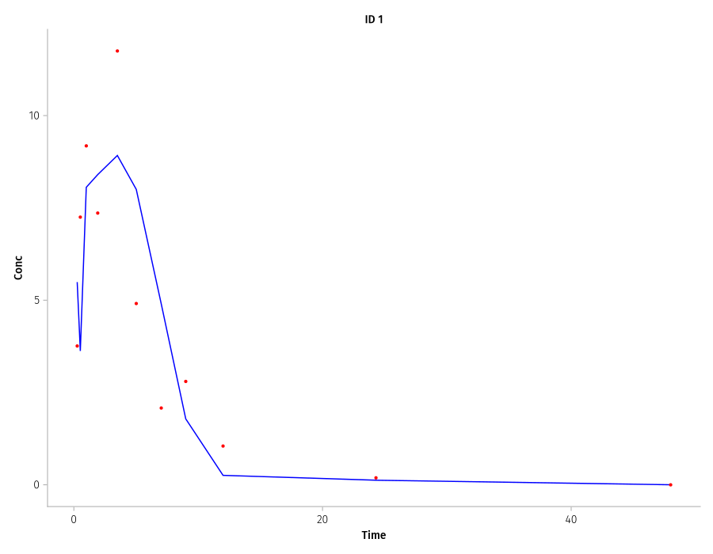

```julia
fig = Figure(size = (900, 700))
for (i, s) in enumerate(ind_sims[1:min(9, end)])
    row, col = divrem(i - 1, 3) .+ (1, 1)
    ax = Axis(fig[row, col], xlabel = "Time", ylabel = "Conc",
        title = "ID " * s.subject.id)
    sdf = DataFrame(s)
    lines!(ax, sdf.time, sdf.dv, color = :blue, linewidth = 1.5)
    # Overlay observed data
    obs_df = DataFrame(pop_real[i])
    obs_rows = @rsubset(obs_df, !ismissing(:dv))
    scatter!(ax, obs_rows.time, obs_rows.dv, color = :red, markersize = 6)
end
fig
```

# 7 DosageRegimen Construction Patterns

`DosageRegimen` is the primary tool for building dosing schedules programmatically:

```julia
# Single oral dose (100 mg to depot compartment)
dr1 = DosageRegimen(100; time = 0.0, cmt = 1)

# Multiple oral doses (200 mg every 8 hours, 15 total doses)
dr2 = DosageRegimen(200; time = 0.0, cmt = 1, addl = 14, ii = 8)

# IV infusion (500 mg over 2 hours to central compartment)
dr3 = DosageRegimen(500; time = 0.0, cmt = 2, rate = 250)  # rate = dose/duration

# Loading dose + maintenance (combine regimens)
iv_load   = DosageRegimen(500; time = 0.0, cmt = 2, duration = 1.0)
oral_maint = DosageRegimen(200; time = 12.0, cmt = 1, addl = 13, ii = 12.0)
combined  = DosageRegimen(iv_load, oral_maint)

# Dose escalation (multiple dose levels)
low_dose  = DosageRegimen(100; time = 0.0, cmt = 1, addl = 6, ii = 24.0)
high_dose = DosageRegimen(200; time = 168.0, cmt = 1, addl = 6, ii = 24.0)
escalation = DosageRegimen(low_dose, high_dose)
```

## 7.1 Building Populations with Covariates

```julia
using Random

# Population with random covariates
Random.seed!(42)
pop = map(1:100) do i
    wt = rand(55.0:0.1:95.0)
    age = rand(20:75)
    sex = rand(["M", "F"])
    Subject(
        id = string(i),
        events = DosageRegimen(200; time = 0.0, cmt = 1, addl = 6, ii = 24.0),
        covariates = (WT = wt, AGE = age, SEX = sex),
        observations = (dv = nothing,),
    )
end
```

# 8 Multiple Dose Simulation

**Multiple Dosing: Accumulation and Steady State**

When a drug is administered repeatedly at a fixed interval $\tau$, the next dose arrives before the previous dose is fully eliminated, leading to **drug accumulation**. The accumulation factor is given by $R = 1/(1 - e^{-k_e \cdot \tau})$, where $k_e$ is the elimination rate constant. Steady state is reached after approximately **4–5 elimination half-lives**, at which point the rate of drug input equals the rate of elimination over one dosing interval. At steady state, the average concentration is:

$$C_{ss,avg} = \frac{F \cdot \text{Dose}}{CL \cdot \tau}$$

where $F = 1$ for intravenous administration. The peak-to-trough fluctuation at steady state depends on the ratio $\tau / t_{1/2}$ — shorter dosing intervals relative to the half-life produce less fluctuation but greater accumulation. Understanding these relationships is essential for selecting dosing regimens that maintain concentrations within the therapeutic window.

Simulate a multiple-dose regimen (200 mg q8h for 5 days):

```julia
md_regimen = DosageRegimen(200, time = 0, cmt = 1, addl = 14, ii = 8)

md_pop = map(1:50) do i
    Subject(id = string(i), events = md_regimen,
        observations = (dv = nothing,))
end

Random.seed!(2024)
md_sims = simobs(sim_model, md_pop, sim_params;
    obstimes = 0:0.5:120)
```

```
Simulated population (Vector{<:Subject})
  Simulated subjects: 50
  Simulated variables: dv
```

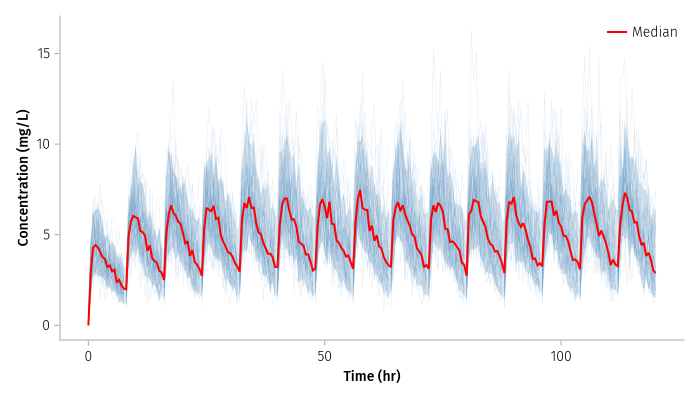

Figure 4: Multiple Dose Simulation: 200 mg q8h (N=50)

```julia
fig = Figure(size = (700, 400))
ax = Axis(fig[1, 1], xlabel = "Time (hr)", ylabel = "Concentration (mg/L)")

for s in md_sims
    sdf = DataFrame(s)
    lines!(ax, sdf.time, sdf.dv, color = (:steelblue, 0.15), linewidth = 0.5)
end

# Compute and plot median + 90% PI
# Stack all subjects, drop missing dv rows, then summarize by time
sim_all = vcat([DataFrame(s) for s in md_sims]...)
sim_obs = dropmissing(sim_all, :dv)
sim_summary = combine(groupby(sim_obs, :time),
    :dv => median => :med,
    :dv => (x -> quantile(x, 0.05)) => :lo,
    :dv => (x -> quantile(x, 0.95)) => :hi)
sort!(sim_summary, :time)
times = sim_summary.time
med = sim_summary.med
lo = sim_summary.lo
hi = sim_summary.hi

band!(ax, times, lo, hi, color = (:steelblue, 0.2))
lines!(ax, times, med, color = :red, linewidth = 2, label = "Median")
axislegend(ax, position = :rt)
fig
```

# 9 Simulation with Parameter Uncertainty

**Why Parameter Uncertainty Matters for Decision-Making**

Point estimates of population parameters ($CL$, $V$, $K_a$, etc.) carry standard errors from the estimation procedure. When simulating predictions for decision-making — such as dose selection for a Phase III trial or probability of target attainment — ignoring this uncertainty produces **overconfident predictions** that understate the true range of plausible outcomes. Propagating parameter uncertainty through simulation provides **prediction intervals** that reflect two distinct sources of variability: (1) inter-individual variability (from $\Omega$), which captures biological differences among patients, and (2) parameter estimation uncertainty (from the variance-covariance matrix of the estimates), which captures the precision of the population-level parameters given the available data. For high-stakes decisions, both sources must be incorporated to produce credible inference.

To account for uncertainty in parameter estimates, resample parameters from their asymptotic distribution:

```julia
# After fitting, simulate with parameter uncertainty
# Pumas can propagate uncertainty from the variance-covariance matrix:
#
# vcov_matrix = vcov(infer(real_fit))
# uncertain_sims = [
#     simobs(sim_model, md_pop, sample_params(real_fit);
#            obstimes = 0:0.5:120)
#     for _ in 1:100
# ]
#
# This gives 100 sets of simulations, each with different
# population parameters drawn from the uncertainty distribution.
```

**Note**

**NONMEM vs Pumas Simulation:**

| NONMEM | Pumas |
| --- | --- |
| `$SIMULATION (seed) ONLYSIM SUB=N` | `simobs(model, pop, params)` |
| Requires dummy data file | Create `Subject` programmatically |
| Post-process with R | `DataFrame(simobs)` directly |
| `$MSFI` for parameter uncertainty | `vcov(infer(fit))` for sampling |

# 10 Reproducibility: Seeds and RNG

Simulation reproducibility requires explicit control of the random number generator:

```julia
using Random

# Global seed — affects all subsequent random calls
Random.seed!(1234)
sims = simobs(model, pop, params; obstimes = 0:0.5:120)

# Local seed — isolated, does not affect global state (preferred for functions)
rng = Random.Xoshiro(1234)
sims = simobs(model, pop, params; obstimes = 0:0.5:120, rng = rng)
```

**Best Practices for Reproducibility**

- **Development:** use local `rng` keyword to keep experiments isolated
- **Final scripts:** set global `Random.seed!()` once at the top for full-script reproducibility
- **Julia’s default RNG** is `Xoshiro` (fast, high-quality) — previously `MersenneTwister`
- Same seed + same code = identical results across runs on the same Julia version

# 11 Study Guide Questions

1. What is the difference between a population simulation and an individual simulation?
2. Why is simulation with parameter uncertainty important for decision-making?
3. How would you simulate 1000 subjects receiving different doses to create a dose-response curve?
4. What is the role of the random seed in simulation reproducibility?

# 12 Supplementary Material

| Topic | Tutorial | Key Additions |
| --- | --- | --- |
| **Lecture: IV Infusion Kinetics** | PK W9 | Steady-state theory, accumulation factor, loading dose rationale |
| **Lecture: Math Foundations of PK** | PK W1c | Exponential/logarithmic functions, first-order rate processes underlying simulation |
| Population generation | [Simulating Populations](https://tutorials.pumas.ai/html/simulation/simulating_populations.html) | `DosageRegimen` construction, `Subject` with covariates, infusions, combined regimens |
| Reproducibility & RNG | [Reproducible Simulations](https://tutorials.pumas.ai/html/simulation/simulating_reproducible.html) | Seeds, `Xoshiro` vs `MersenneTwister`, local vs global reproducibility, `rand_covariates()` |